# Project file organization and documentation

Week 2 – Lecture B

Author

Affiliations

Jelmer Poelstra

[CFAES Bioinformatics Core, Ohio State University](https://go.osu.edu/bioinformatics-core)

[Dept. of Plant Pathology, Ohio State University](https://plantpath.osu.edu)

Published

August 29, 2026

Modified

August 10, 2026

## 1 Introduction

### 1.1 Learning goals

Learn best practices for:

- Organization and management of your research project files
- Documentation of your research project

### 1.2 Lecture context & overview

This lecture covers the principles behind, and practice of, good **research project documentation and file organization**. Why is this important? Thoughtful and systematic project documentation and organization facilitates:

- Collaboration with others and your future self
- Reproducibility of your research
- Your ability to automate your work
- Your ability to use version control (week 4)

Relatedly, Noble (2009) cited the following two principles underlying his recommendations on this topic:

> 1. Someone unfamiliar with your project should be able to look at your computer files and understand in detail what you did and why.
> 2. Everything you do, you will probably have to do over again.

Keep those principles in mind while we discuss the recommendations below!

## 2 File organization and management

I will recommend the following set of practices for research project file organization and management:

- Use one folder (folder hierarchy) for one project
- Within your project folder, separate different kinds of files using a consistent subfolder structure
- Avoid manual editing of your data and your results
- Follow file and folder naming practices that favor machine- *and* human-readability
- Use so-called “relative paths” to refer to files and folders within your project

Let’s get into these!

### 2.1 Use one folder for one project

For one research project, all files should be contained in one folder — or we should perhaps say one *hierarchy* of folders, since you can -and should!- make liberal use of “subfolders”. Regardless, this recommendation entails that you should not store files associated with one project scattered across a computer.

Here is a minimal example diagram of two properly separated and systematically organized research project folders:

[figure not shown]

Two research project folder hierarchies. Each box is a folder.  
The way to read this is that the blue `data` folder is contained within the `project1` folder,  
which in turn is contained within the Home folder (your personal Home location on the computer).

This means that for a given research project, you can pinpoint a specific folder, like `project1` in the image above…

1. that contains *all* files related to that project,
2. while not containing *any* files unrelated to that project.

When you have a single folder hierarchy for each project, it is easier to:

- Find files
- Share or back up your entire project
- Avoid throwing away stuff in error

**WarningHow to define and separate projects in more complicated scenarios? *(Click to expand)**

From Wilson et al. (2017):

> *As a rule of thumb, divide work into projects based on the overlap in data and code files:*
> - *If 2 research efforts share no data or code,* *they will probably be easiest to manage independently.*
> - *If they share more than half of their data and code, they are probably best* *managed together.*
> - *If you are building tools that are used in several projects,* *the common code should probably be in a project of its own.*

#### 2.1.1 Projects with shared data or code

To access files outside of the project (e.g., shared across projects), it is easiest to create **links** (i.e. shortcuts/aliases) to these files:

[figure not shown]

The data is located in `project1` but used in both projects.  
`project2` contains a link to the data.

But shared data or scripts are generally better stored in separate folders, and then linked to by each project using them:

[figure not shown]

Now, the data is in it’s own top-level folder, with links to it in both projects.

These strategies do decrease the portability of your project, and moving the shared files even within your own computer will cause links/shortcuts to break. A more portable method is to **keep shared (multi-project) files online** — this is especially feasible for **scripts** under version control:

[figure not shown]

A set of scripts shared by two projects is stored in an online repository like at GitHub.

For **data**, this is also possible but often not practical due to file sizes._ It’s easier after data has been deposited in a public repository._

### 2.2 Separate different kinds of files using a consistent folder structure

Within your project’s folder hierarchy, use subfolders to separate different kinds of files, such as files that contain:

- Code
- Data
- Results (of data processing and analysis)

Here is one good way of organizing project files with a set of top-level folders and some standard documentation files:

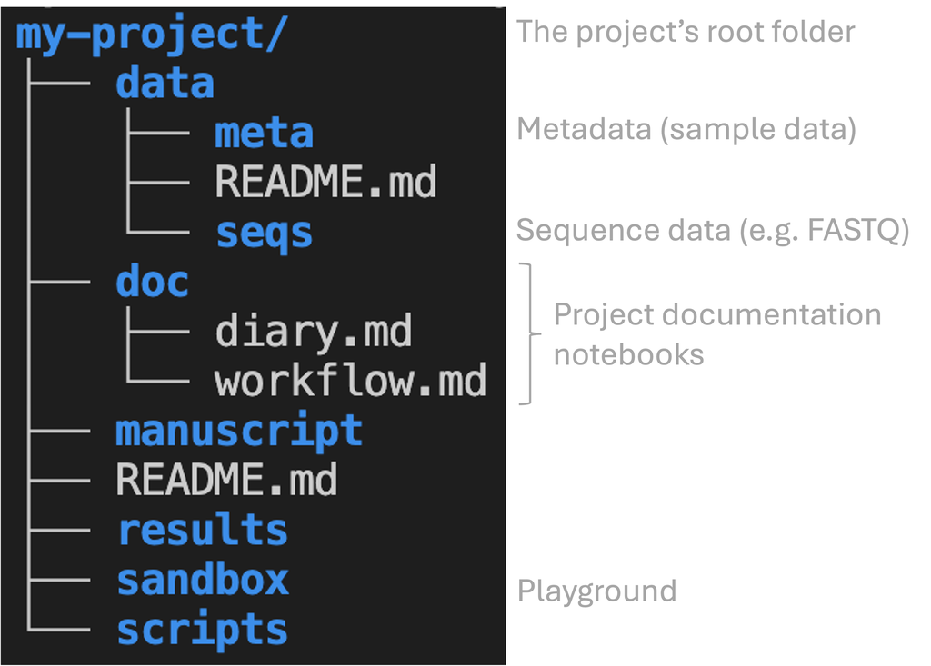

In this example project folder hierarchy, the hierarchical folder structure is indicated with lines and indentation: the root (top-level) project folder is `my-project`, which e.g. contains the `data` folder that in turn contains other folders. Folders are shown in blue and files in white. The last section of this page will cover the `.md` documentation files shown.

Another important good practice is to use subfolders liberally and hierarchically. For example, **create subfolders within `results` for each step in your project**. At least in in omics data analysis, it is often most convenient to mostly name these subfolders after the tool (piece of software) it uses:

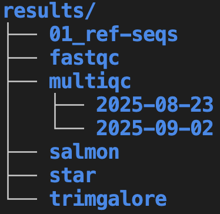

*An example showing subfolders within `results` mostly organized by the software that produced the results. Separate runs for MultiQC are grouped into further subfolders by date.*

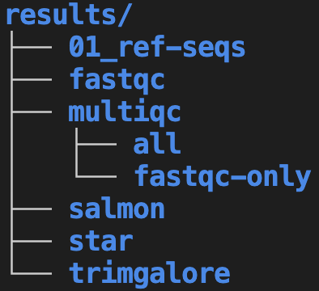

Like the example on the left, but here, separate runs for MultiQC are grouped into subfolders using a description.

In the above examples:

- While most subfolders are organized by and named after the software that produced each set of results, other kinds of categories and names make more sense in some cases. For example, `01_ref-seqs` represents a folder with reference genome sequences. The `01_` prefix is used to ensure this folder shows up at the top (see the box below, and the section on file naming, for more on file/folder *numbering*).
- Say that the MultiQC program was run multiple times. On the left, these folders are named after the run date, whereas on the right, folder names describe what each run was for. Both of these options have pros and cons – for example, always using a date is simple and consistent but is less clear about the purpose of each folder.

The two different treatments of `multiqc` subfolders illustrates that **for many of the recommendations presented here, multiple reasonable alternatives do exist.**

**NoteSome alternative file organization and naming options *(Click to expand)**

The above recommendations only go so far, and several details can be modified depending on personal preferences and project specifics. For example:

- You can start folder and file names with numbers so that they would automatically be sorted in a logical way (i.e. step 1 then step 2, etc.), e.g. within `results` and/or `scripts` as shown below. That can be really neat and clear but the drawback of this is that if you later *insert* a step, a lot of renaming needs to be done…

  ```
  |-- results/
  |   |-- 01_reference-seqs/
  |   |-- 02_fastqc/
  |   |-- 03_multiqc/
  |   |-- 04_trimgalore/
  |   |-- 05_star/
  |   |-- 06_salmon/
  |-- scripts/
  |   |-- 01_download-reference.sh
  |   |-- 02_fastqc.sh
  ```

- Several of these folders could be named differently, such as:
  - Some researchers prefer `analysis` instead of `results`
  - Some researchers prefer `src` (“source”) instead of `scripts`
- Some recommendations, such as by Buffalo (2015), use `data/raw` and `data/processed` folders. However, this blurs the line between data and analysis results, and I much prefer to put “processed data” within `results`.
- Noble (2009) recommends that subfolders within `results` are initially organized by date and then by topic/software (e.g: `results/2026-08-30/multiqc`). I personally don’t think this works well for most omics data analysis.

### 2.3 Avoid manual editing of data and results

Once they have been produced, **raw data files should never be edited**. Instead, any data processing or even correction should be done with *separate copies* of the data.

Additionally, you should avoid *manually* editing any data and results files. Instead, such editing should be done using code. As Abdill et al. (2024) explain (my bolding):

> For example, if script A processes raw data into a table of gene expression levels, and script B summarizes this table by pathway, we should be concerned if there is a step after script A that requires a user to open the table and edit fields by hand to prepare the data for script B. **Such quick fixes can be tempting**, but they also add risk: A researcher could easily add a typo, corrupt a file in unexpected ways, or forget the step altogether.

When you use *code* to make such fixes, it can be included as part of your project’s “workflow” and therefore be reproducible.

That also makes these fixes much easier to repeat if needed. Recall the second of Noble (2009)’s guiding principles mentioned above: *“Everything you do, you will probably have to do over again.”* While a manual fix may be quicker if it really only needed to be done once, it is common to have to repeat things in practice, such that writing code to do the fix can also end up saving time.

**TipTreatment of data versus results**

### 2.4 Use machine- and human-readable file names

Here are three key principles for good file names ([from Jenny Bryan](https://speakerdeck.com/jennybc/how-to-name-files)) — they should:

- Be machine-readable
- Be human-readable
- Wherever appropriate, be ordered correctly by default alphanumeric file sorting

We’ll go into each of these aspects below.

#### 2.4.1 Machine-readable

Consistent and informative naming helps you to programmatically find and process files.

- **Don’t use spaces in file names**, as these lead to inconvenience at best and disaster at worst when working in the Unix Shell – and to some extent with other programming languages as well.
- More generally, only use the following characters in file names:
  - Alphanumeric characters (`A-Za-z0-9`)
  - Underscores (`_`)
  - Hyphens (AKA dashes, `-`)
  - Periods (AKA dots, `.`)
- Where appropriate, you can provide **metadata** like Sample ID, date, and treatment in file names:
  - `sample032_2016-05-03_low.txt`
  - `samples_soil_treatmentA_2019-01.txt`

  With such file names, you can easily find files from e.g. a certain month or treatment.

#### 2.4.2 Human-readable

While machine-readability in file names is important, this should not go at the expense of human readability. For example, from Wilson et al. (2017):

> *“Name all files to reflect their content or function.* *For example, use names such as `bird_count_table.csv`, `manuscript.md`,* *or `sightings_analysis.py`.*”

Not only are the above file names informative, they are also human-readable thanks to the use of underscores (`_`) to separate words. Just because you shouldn’t use spaces in file names, doesn’t mean you should name your files like `firstattemptatthissequenceanalysis.R`!

More specifically, while there are multiple reasonable methods, here is one good way I will recommend:

- Use **underscores** (`_`) to delimit units you may later want to separate on: sampleID, batch, treatment, date.
- Within such units, use **dashes** (`-`) to delimit words: `grass-samples`.
- Limit the use of **periods** (`.`) to indicate file extensions (e.g., `.R`, `.sh`).
- Generally *avoid capitals*.

For example, for a set of BAM (`.bam`) sequence alignment files:

```
mmus001_filtered-by-mq30_sorted.bam
mmus002_filtered-by-mq30_sorted.bam
...
mmus086_filtered-by-mq30_sorted.bam
```

Most important, however, is that once you find a scheme that works for you, you **use that scheme consistently**.

#### 2.4.3 File names that are automatically ordered appropriately

Within file listings in computer’s file browsers (and in the Unix Shell, as you’ll see), default file ordering is typically alphanumerical. With that in mind:

- **Dates** should be written as `YYYY-MM-DD`: for example, `2020-10-11`. Not only does this lead to files being ordered correctly, this format is also unambiguous, preventing confusion between month and day in particular.
- Use **leading zeros** for correct alphanumeric sorting: `sample005`. If you don’t do this, `sample10` will appear before `sample2`, etc.:

*Without leading zeros:*

```
sample1
sample10
sample11
sample2
sample3
...
```

*With leading zeros:*

```
sample01
sample02
sample03
...
sample10
sample11
```

- You may want to **group similar files together** by starting with the same phrase, and to **number scripts** by execution order – for example:

```
DE-01_normalize.R
DE-02_test.R
DE-03_process-significant.R
preprocess-01_fastqc.sh
preprocess-02_multiqc.sh
```

### 2.5 Use relative paths

To understand this recommendation, you first need to learn more about paths and folder structures.

#### 2.5.1 Terminology and concepts related to paths

- “Directory” (or “**dir**” for short) is another term for *folder* that is commonly used e.g. in coding contexts.
- A “**working dir**” is the dir that you are currently located in. In a command-line interface, like the Unix shell you’ll learn after this, you are *always* in a certain working dir (and the same is basically true in a regular file browser).
- “Unix-based” operating systems include MacOS and Linux (note: OSC uses Linux), and these have a single starting point to the directory structure: **the root directory, depicted as `/`**[^1].

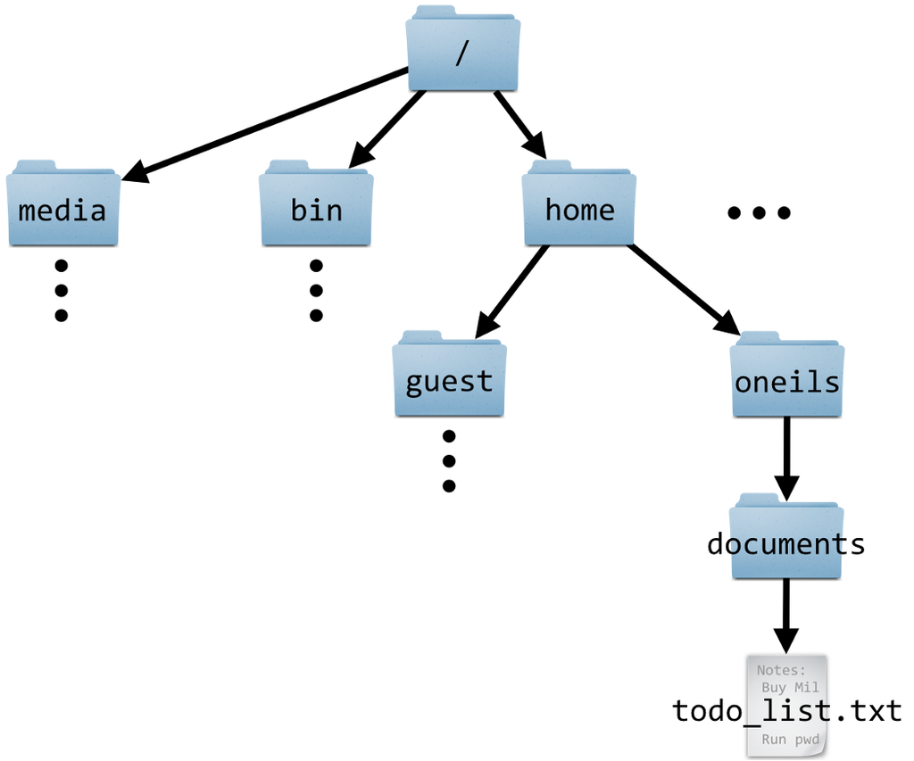

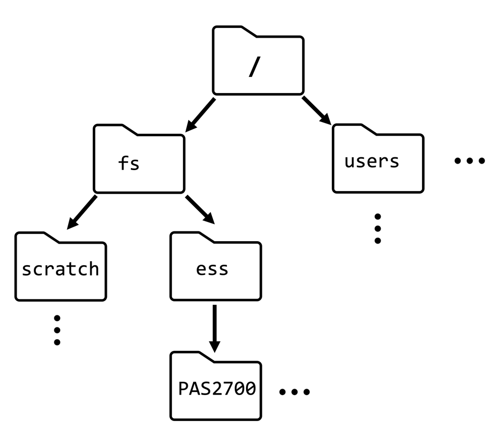

Key directories in OSC’s dir structure

**In the left-hand schematic above, what is the path to the file `todo_list.txt`? *(Click for the solution)**

`/home/oneils/documents/todo_list.txt`

#### 2.5.2 Absolute versus relative paths

The location of any file or dir can be referred to in two different ways, using either:

|  | Absolute paths | Relative paths |
| --- | --- | --- |
| Meaning | Start from the computer’s root dir | Start from your working dir |
| Recognized by | A leading `/` [^3] | No leading `/` |
| Examples | `/fs/ess/PAS3493` | – `data/meta/metadata.tsv` – `todo_list.txt` |
| Analogy | GPS coordinates for a geographical location: valid regardless of where you are | Directions along the lines of “take the second left”: validity depends on your current location |

**In the examples above, how can the mere file name `todo_list.txt` represent a path? *(Click for the solution)**

A file name like `todo_list.txt`, with no directories included, can represent a relative path that implies the file is in our current working dir.

Alternatively, you can be explicit about the fact that a file is in your current working dir by using a `./` preface, e.g.: `./todo_list.txt`. Next week, you’ll learn more about the `.` notation for the current working dir.

#### 2.5.3 Why you should prefer relative paths

Given that **absolute paths** do not depend on your working dir, while **relative paths** do and therefore won’t work if you’re elsewhere — don’t absolute paths sound better? What could be a disadvantage of them?

The disadvantages of absolute paths are that they:

- Don’t generally work across computers
- Break when you move your entire project dir

Relative paths, on the other hand, can continue to work after moving project dirs within and between computers. This is the case as long as you **consistently use the project’s top-level dir as your working dir** (this is another general recommendation), i.e. as the starting point of your relative paths. For example:

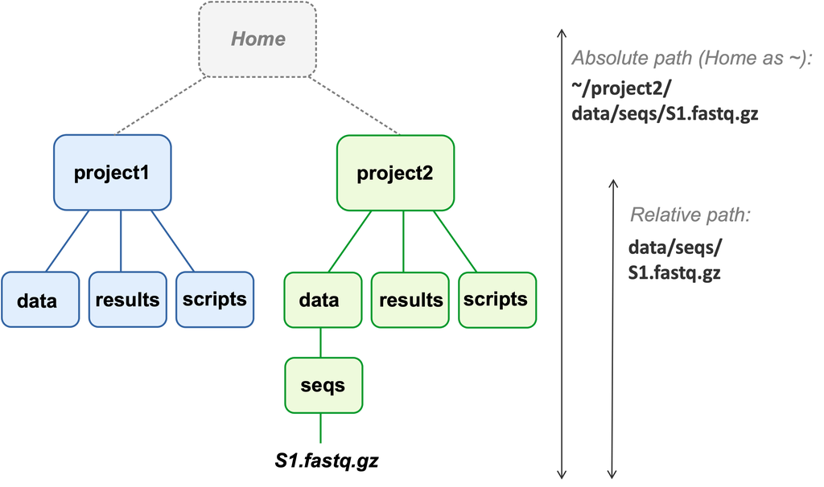

Two project dir hierarchies, and the absolute and relative paths to a FASTQ file (FASTQ files contain HTS reads).  
Following best practices, the relative path starts from the relevant project’s top-level dir.  
(Note that `~` is a way to refer to your Home folder.)

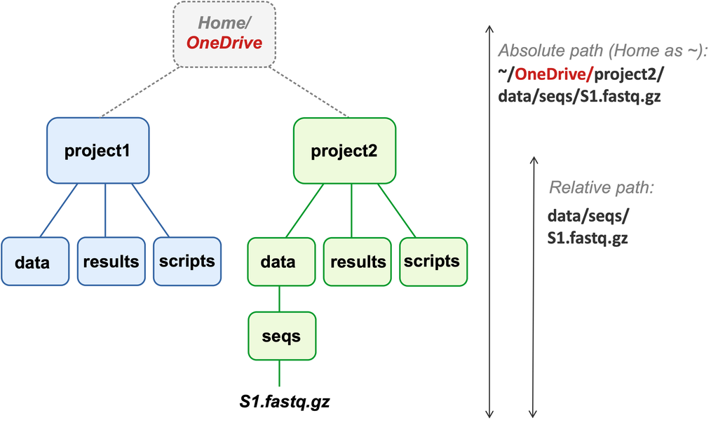

Now, both projects were moved into `OneDrive`.  
The absolute path to the FASTQ file has changed,  
but the relative path from the project’s top-level dir remains the same.

## 3 Documenting your research project

It is essential to document what you are doing while working on your research project. This is not always easy! It can be much more appealing to just keep chugging along. In the moment, it may seem like a waste of time to make notes on what *then and there* is obvious: you will likely have a clear picture of what you did, say, this morning.

However, you won’t have such a clear picture a month later, and a collaborator won’t either. Therefore, you should often make a **conscious effort at taking a step back, slowing down,** **and writing down what you did and why**.

An important advantage of using code to do your analyses, like you will learn in this course, is that *code is self-documenting* to a much larger extent than pointing and clicking in a program with a Graphical User Interface (GUI). However, this should not make you complacent and skip documenting what you did.

How should you do this in practice?

### 3.1 Always maintain README and other documentation files

Your documentation files should contain all information needed to reproduce your research. Some specific examples:

- Where/when/how each data and metadata file originated
- Versions of software, databases, reference genomes

In computational work, it is common practice to store project documentation in files that are called (or include the word) “README”, e.g. `README.md`. Additionally, it often makes sense to use a few kinds of other documentation files as well, like in the example we saw earlier:

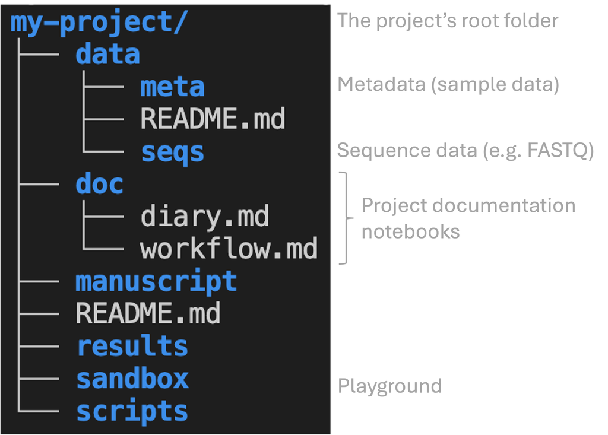

Below, we’ll discuss the three types of documentation files shown in the image above. While **you should always have a README file in the top-level folder of your project**, you may end up wanting to organize other files differently, but take this as a starting point:

#### 3.1.1 README file(s)

Assuming that you keep separate “lab notebook” and “protocol” files (see below), this README file does not need to be very long, but should for example contain:

- A brief overview of the project
- An explanation of your project’s folder structure. What can be found where? How are the files named?
- Details about the data, such as how and when it was obtained
- Contact information

You may choose to use multiple README files, including ones in key subfolders such as `data`, `results`, and `scripts`, each of which describe the files in that folder.

#### 3.1.2 Electronic lab notebook (organized by date)

Keep an electronic lab notebook or “diary” with chronological entries that documents everything you did (`doc/diary.md` in the example above):

- This file should include things like what code you ran and why, quick interpretations of results, and so on. It can also include notes on meetings and copies of important emails.
- This should not be a “clean” document — for example, you should not remove entries on say failed experiments and analyses, or consideration/testing of methods that you did not include in your final analyses.

#### 3.1.3 Final workflow/protocol file (organized in order of execution)

Write a separate file (`doc/workflow.md` in the example above) that contains the code and other details needed to **rerun** the final analyses you performed for your project:

- Entries should be organized by the most sensible *final* order of execution
- This *should* be a “clean” document, and omit any steps you don’t consider part of your final results.

### 3.2 Use plain text files

In this course, we’ll be working almost exclusively with so-called “**plain-text**” files (files with `.txt` and related extensions). These are files that can be opened by any text editor on any computer.

Plain-text files are different from so-called “binary” and proprietary formats like Microsoft Excel (e.g. `.xlsx`) or Word (e.g. `.docx`), which can often be opened and edited only in their respective programs. That can pose many problems: for example, these programs are not always available, and version mismatches may make files impossible to open.

Many common sequence file formats are also plain-text. And while their simplicity may seem limiting, **plain-text files are generally preferable for reproducible science** because they:

- Can be accessed on any computer, including over remote connections
- Can be operated on by Unix shell commands and any other programming language
- Are future-proof
- Can be version-controlled appropriately

For these reasons, I recommend to also use a plain-text format to document your research, and you will practice with that during the course. Specifically, you’ll use so-called **Markdown** files (`.md`), which strike a nice balance between ease of writing and reading on the one hand, and formatting options on the other hand. In the next lecture, you will learn the basics of the Markdown “syntax”.

#### Discussion: Do you have a note-keeping/documentation system?

- What kinds of files do you use?
- How do you organize these files?
- Do you use any specialized electronic lab notebook systems?

## 4 In closing

Some of these project organization and documentation recommendations may seem a bit abstract this early in the course. Therefore, I recommend that you revisit this page later on in the course.

You may also wonder how file organization works when your work is done on multiple computers, like your own laptop in addition to OSC. This is a question we’ll get back to in weeks 4 and 5.

Back to top

## References

Abdill, Richard J., Emma Talarico, and Laura Grieneisen. 2024. “A How-to Guide for Code Sharing in Biology.” *PLOS Biology* 22 (9): e3002815. https://doi.org/10.1371/journal.pbio.3002815.

Buffalo, Vince. 2015. *Bioinformatics Data Skills [Reproducible and Robust Research With Open Source Tools]*. First edition. O’Reilly.

Noble, William Stafford. 2009. “A Quick Guide to Organizing Computational Biology Projects.” *PLOS Computational Biology* 5 (7): e1000424. https://doi.org/10.1371/journal.pcbi.1000424.

O’Neil, Shawn T. 2019. *A Primer for Computational Biology*. Oregon State University. https://open.oregonstate.education/computationalbiology/.

Wilson, Greg, Jennifer Bryan, Karen Cranston, Justin Kitzes, Lex Nederbragt, and Tracy K. Teal. 2017. “Good Enough Practices in Scientific Computing.” *PLOS Computational Biology* 13 (6): e1005510. https://doi.org/10.1371/journal.pcbi.1005510.

## Footnotes

[^1]: Windows computers often contain multiple dir structures instead, but each of these similarly have roots / starting points, such as `C:\`.
[^2]: But Windows uses backslashes (`\`).
[^3]: This leading `/` can be *implicit* though: For example, `~` is a shortcut that expands to an absolute path to your Home directory.